# Introducing eemR

The [`eemR`](https://github.com/PMassicotte/eemR) package implements various functions used calculate metrics from excitation-emission matrix (EEM) as well as to preform pre-processing corrections before PARAFAC analysis. All functions from this package start with the `eem_` prefix. Please note this is a very alpha version of the package for testing purpose only.

```r
library(eemR)
ls("package:eemR")
```

```
##  [1] "absorbance"              "eem_bind"
##  [3] "eem_biological_index"    "eem_coble_peaks"
##  [5] "eem_cut"                 "eem_export_matlab"
##  [7] "eem_extract"             "eem_fluorescence_index"
##  [9] "eem_humification_index"  "eem_inner_filter_effect"
## [11] "eem_names"               "eem_names<-"
## [13] "eem_peaks"               "eem_raman_normalisation"
## [15] "eem_read"                "eem_remove_blank"
## [17] "eem_remove_scattering"   "eem_set_wavelengths"
```

The package can be installed using the following command.

```r
devtools::install_github("PMassicotte/eemR")
```

## Reading excitation-emission

At the moment, to following EEM types are supported:

- Cary Eclipse `.csv` files
- Aqualog `.dat` files

EEM can be read using the `eem_read()` function. *Please fill an [issue](https://github.com/PMassicotte/eemR/issues) if you have other file formats you would like to add to the package*.

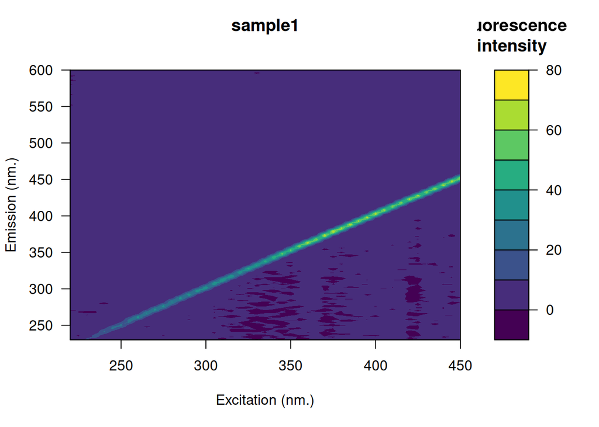

```r
library(eemR)

## Reading a single eem
file <- system.file("extdata/cary/scans_day_1", "sample1.csv", package = "eemR")
eem <- eem_read(file, import_function = "cary")

plot(eem)
```

# Implemented metrics

The current implemented metrics are:

1. The fluorescence index (FI).
2. The fluorescence peaks.
3. The fluorescence humification index (HIX).
4. The biological fluorescence index (BIX).

```r
library(eemR)

folder <- system.file("extdata/cary/scans_day_1", package = "eemR")
eem <- eem_read(folder, import_function = "cary")

eem_fluorescence_index(eem)
```

```
##    sample         fi
## 1    nano -0.5932057
## 2 sample1  1.2647823
## 3 sample2  1.4553330
## 4 sample3  1.3294132
```

```r
eem_coble_peaks(eem)
```

```
##    sample         b         t        a          m         c
## 1    nano 0.8745673 0.1401188 0.140175 0.09653326 0.1255788
## 2 sample1 1.5452981 1.0603312 3.731836 2.42409567 1.8149415
## 3 sample2 1.2629968 0.6647042 1.583489 1.02359302 0.7709074
## 4 sample3 1.4740862 1.3162812 8.416034 6.06335506 6.3179129
```

```r
eem_humification_index(eem)
```

```
##    sample        hix
## 1    nano  0.5568136
## 2 sample1  6.3795618
## 3 sample2  4.2548483
## 4 sample3 13.0246234
```

```r
eem_biological_index(eem)
```

```
##    sample       bix
## 1    nano 2.6812045
## 2 sample1 0.7062640
## 3 sample2 0.8535423
## 4 sample3 0.4867927
```

# PARAFAC pre-processing

The `eem_remove_scattering()` function removes both Raman and Rayleigh scattering from EEMs.

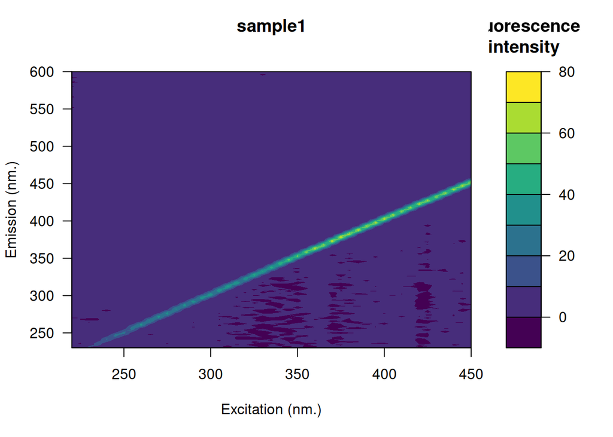

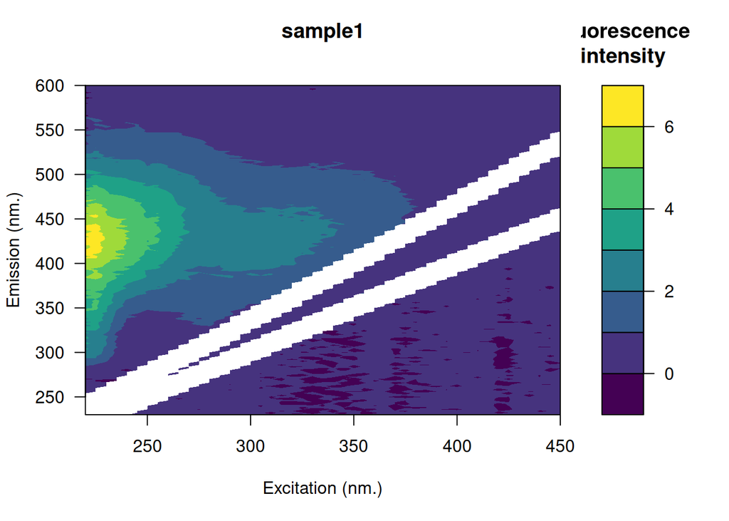

```r
file <- system.file("extdata/cary/scans_day_1", "sample1.csv", package = "eemR")
eem <- eem_read(file, import_function = "cary")

res <- eem_remove_scattering(eem = eem, type = "raman", order = 1, width = 10)
res <- eem_remove_scattering(eem = res, type = "rayleigh", order = 1, width = 10)

plot(eem)
plot(res)
```

## Blank removal

The `eem_remove_blank()` function subtract blank (miliq) water from eem. Scatter bands can often be reduced by subtracting water blank.

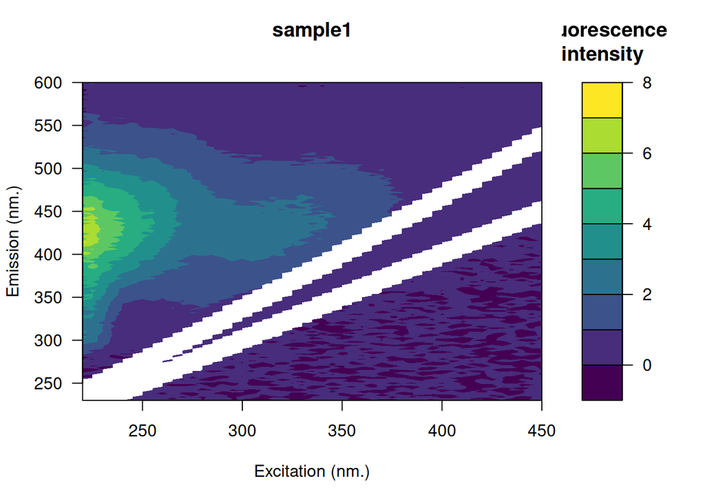

```r
file <- system.file("extdata/cary/scans_day_1", "nano.csv", package = "eemR")
blank <- eem_read(file, import_function = "cary")

res <- eem_remove_blank(res, blank)

plot(res)
```

## Raman normalization

The `eem_raman_normalisation()` function implement a simple calibration method for fluorescence intensity using only the integrated area of a water Raman peak.

```r
res <- eem_raman_normalisation(res, blank)
```

```
## Raman area: 9.540904
```

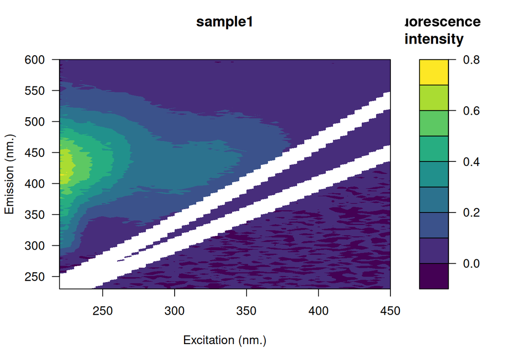

```r
plot(res)
```

## Inner-filter effect correction

To account for reabsorption of the light emitted by fluorophores in the water, absorbance spectra are used for correction of both primary and secondary inner filtering effects in the EEMs.

```r
data("absorbance")

res <- eem_inner_filter_effect(res, absorbance, 1)
```

```
## sample1
## Range of IFE correction factors: 1.0112 1.5546
## Range of total absorbance (Atotal) : 0.0096 0.3832
```

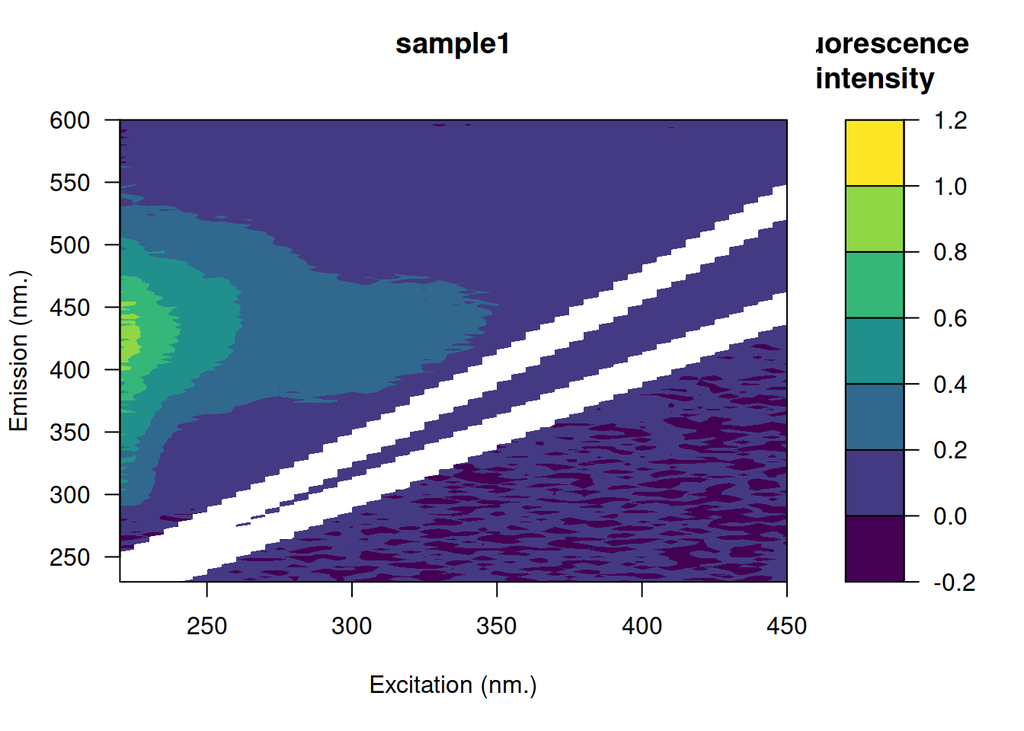

```r
plot(res)
```

## Export to Matlab

PARAFAC analysis was made easy with the fantastic Matlab [`drEEM`](http://www.models.life.ku.dk/drEEM) toolbox. The function `eem_export_matlab()` can be used to export the EEMs into a `m-file` directly usable in Matlab by the `drEEM` toolbox.

```r
folder <- system.file("extdata/cary/scans_day_1", package = "eemR")
eem <- eem_read(folder, import_function = "cary")

filename <- paste(tempfile(), ".mat", sep = "")

eem_export_matlab(filename, eem)
```

```
## Successfully exported 4 EEMs to /tmp/RtmpHY1kWm/filec77b02f24600b.mat.
```

Note that the name of the structure generated by the function will be `OriginalData` to *complement* with PARAFAC standard. Then, the importation into Matlab is made easy using the `load()` function.

```matlab
load('FileName.mat');
```